# Risk Factor Analysis

## Outcome Variable

**Outcome Variable:** ever_swasted

## Predictor Variables

**Intervention Variable:** impsan

**Adjustment Set:**

- arm
- sex
- W_mage
- meducyrs
- feducyrs
- hhwealth_quart
- hfoodsec
- W_mhtcm
- W_mwtkg
- W_mbmi
- W_nrooms
- W_nchldlt5
- W_parity
- impfloor
- safeh20
- delta_W_mage
- delta_meducyrs
- delta_feducyrs
- delta_hhwealth_quart
- delta_hfoodsec
- delta_W_mhtcm
- delta_W_mwtkg
- delta_W_mbmi
- delta_W_nrooms
- delta_W_nchldlt5
- delta_W_parity
- delta_impfloor
- delta_safeh20

## Stratifying Variables

The analysis was stratified on these variable(s):

- agecat
- studyid
- country

## Data Summary

| agecat | studyid | country | impsan | ever_swasted | n_cell | n |
| --- | --- | --- | --- | --- | --- | --- |
| 0-24 months (no birth wast) | COHORTS | GUATEMALA | 1 | 0 | 81 | 870 |
| 0-24 months (no birth wast) | COHORTS | GUATEMALA | 1 | 1 | 0 | 870 |
| 0-24 months (no birth wast) | COHORTS | GUATEMALA | 0 | 0 | 763 | 870 |
| 0-24 months (no birth wast) | COHORTS | GUATEMALA | 0 | 1 | 26 | 870 |
| 0-24 months (no birth wast) | COHORTS | INDIA | 1 | 0 | 1908 | 5168 |
| 0-24 months (no birth wast) | COHORTS | INDIA | 1 | 1 | 58 | 5168 |
| 0-24 months (no birth wast) | COHORTS | INDIA | 0 | 0 | 3009 | 5168 |
| 0-24 months (no birth wast) | COHORTS | INDIA | 0 | 1 | 193 | 5168 |
| 0-24 months (no birth wast) | COHORTS | PHILIPPINES | 1 | 0 | 169 | 1185 |
| 0-24 months (no birth wast) | COHORTS | PHILIPPINES | 1 | 1 | 10 | 1185 |
| 0-24 months (no birth wast) | COHORTS | PHILIPPINES | 0 | 0 | 917 | 1185 |
| 0-24 months (no birth wast) | COHORTS | PHILIPPINES | 0 | 1 | 89 | 1185 |
| 0-24 months (no birth wast) | CONTENT | PERU | 1 | 0 | 200 | 215 |
| 0-24 months (no birth wast) | CONTENT | PERU | 1 | 1 | 1 | 215 |
| 0-24 months (no birth wast) | CONTENT | PERU | 0 | 0 | 14 | 215 |
| 0-24 months (no birth wast) | CONTENT | PERU | 0 | 1 | 0 | 215 |
| 0-24 months (no birth wast) | JiVitA-3 | BANGLADESH | 1 | 0 | 17885 | 26502 |
| 0-24 months (no birth wast) | JiVitA-3 | BANGLADESH | 1 | 1 | 626 | 26502 |
| 0-24 months (no birth wast) | JiVitA-3 | BANGLADESH | 0 | 0 | 7670 | 26502 |
| 0-24 months (no birth wast) | JiVitA-3 | BANGLADESH | 0 | 1 | 321 | 26502 |
| 0-24 months (no birth wast) | JiVitA-4 | BANGLADESH | 1 | 0 | 3991 | 5381 |
| 0-24 months (no birth wast) | JiVitA-4 | BANGLADESH | 1 | 1 | 170 | 5381 |
| 0-24 months (no birth wast) | JiVitA-4 | BANGLADESH | 0 | 0 | 1159 | 5381 |
| 0-24 months (no birth wast) | JiVitA-4 | BANGLADESH | 0 | 1 | 61 | 5381 |
| 0-24 months (no birth wast) | LCNI-5 | MALAWI | 1 | 0 | 3 | 810 |
| 0-24 months (no birth wast) | LCNI-5 | MALAWI | 1 | 1 | 0 | 810 |
| 0-24 months (no birth wast) | LCNI-5 | MALAWI | 0 | 0 | 800 | 810 |
| 0-24 months (no birth wast) | LCNI-5 | MALAWI | 0 | 1 | 7 | 810 |
| 0-24 months (no birth wast) | MAL-ED | BANGLADESH | 1 | 0 | 193 | 242 |
| 0-24 months (no birth wast) | MAL-ED | BANGLADESH | 1 | 1 | 11 | 242 |

[output cut: 174 more lines]

The following strata were considered:

- agecat: 0-24 months (no birth wast), studyid: COHORTS, country: GUATEMALA
- agecat: 0-24 months (no birth wast), studyid: COHORTS, country: INDIA
- agecat: 0-24 months (no birth wast), studyid: COHORTS, country: PHILIPPINES
- agecat: 0-24 months (no birth wast), studyid: CONTENT, country: PERU
- agecat: 0-24 months (no birth wast), studyid: JiVitA-3, country: BANGLADESH
- agecat: 0-24 months (no birth wast), studyid: JiVitA-4, country: BANGLADESH
- agecat: 0-24 months (no birth wast), studyid: LCNI-5, country: MALAWI
- agecat: 0-24 months (no birth wast), studyid: MAL-ED, country: BANGLADESH
- agecat: 0-24 months (no birth wast), studyid: MAL-ED, country: BRAZIL
- agecat: 0-24 months (no birth wast), studyid: MAL-ED, country: INDIA
- agecat: 0-24 months (no birth wast), studyid: MAL-ED, country: NEPAL
- agecat: 0-24 months (no birth wast), studyid: MAL-ED, country: PERU
- agecat: 0-24 months (no birth wast), studyid: MAL-ED, country: SOUTH AFRICA
- agecat: 0-24 months (no birth wast), studyid: MAL-ED, country: TANZANIA, UNITED REPUBLIC OF
- agecat: 0-24 months (no birth wast), studyid: NIH-Birth, country: BANGLADESH
- agecat: 0-24 months (no birth wast), studyid: NIH-Crypto, country: BANGLADESH
- agecat: 0-24 months (no birth wast), studyid: PROVIDE, country: BANGLADESH
- agecat: 0-6 months (no birth wast), studyid: COHORTS, country: GUATEMALA
- agecat: 0-6 months (no birth wast), studyid: COHORTS, country: INDIA
- agecat: 0-6 months (no birth wast), studyid: COHORTS, country: PHILIPPINES
- agecat: 0-6 months (no birth wast), studyid: CONTENT, country: PERU
- agecat: 0-6 months (no birth wast), studyid: JiVitA-3, country: BANGLADESH
- agecat: 0-6 months (no birth wast), studyid: JiVitA-4, country: BANGLADESH
- agecat: 0-6 months (no birth wast), studyid: LCNI-5, country: MALAWI
- agecat: 0-6 months (no birth wast), studyid: MAL-ED, country: BANGLADESH
- agecat: 0-6 months (no birth wast), studyid: MAL-ED, country: BRAZIL
- agecat: 0-6 months (no birth wast), studyid: MAL-ED, country: INDIA
- agecat: 0-6 months (no birth wast), studyid: MAL-ED, country: NEPAL
- agecat: 0-6 months (no birth wast), studyid: MAL-ED, country: PERU
- agecat: 0-6 months (no birth wast), studyid: MAL-ED, country: SOUTH AFRICA
- agecat: 0-6 months (no birth wast), studyid: MAL-ED, country: TANZANIA, UNITED REPUBLIC OF
- agecat: 0-6 months (no birth wast), studyid: NIH-Birth, country: BANGLADESH
- agecat: 0-6 months (no birth wast), studyid: NIH-Crypto, country: BANGLADESH
- agecat: 0-6 months (no birth wast), studyid: PROVIDE, country: BANGLADESH
- agecat: 6-24 months, studyid: COHORTS, country: GUATEMALA
- agecat: 6-24 months, studyid: COHORTS, country: INDIA
- agecat: 6-24 months, studyid: COHORTS, country: PHILIPPINES
- agecat: 6-24 months, studyid: CONTENT, country: PERU
- agecat: 6-24 months, studyid: JiVitA-3, country: BANGLADESH
- agecat: 6-24 months, studyid: JiVitA-4, country: BANGLADESH
- agecat: 6-24 months, studyid: LCNI-5, country: MALAWI
- agecat: 6-24 months, studyid: MAL-ED, country: BANGLADESH
- agecat: 6-24 months, studyid: MAL-ED, country: BRAZIL
- agecat: 6-24 months, studyid: MAL-ED, country: INDIA
- agecat: 6-24 months, studyid: MAL-ED, country: NEPAL
- agecat: 6-24 months, studyid: MAL-ED, country: PERU
- agecat: 6-24 months, studyid: MAL-ED, country: SOUTH AFRICA
- agecat: 6-24 months, studyid: MAL-ED, country: TANZANIA, UNITED REPUBLIC OF
- agecat: 6-24 months, studyid: NIH-Birth, country: BANGLADESH
- agecat: 6-24 months, studyid: NIH-Crypto, country: BANGLADESH
- agecat: 6-24 months, studyid: PROVIDE, country: BANGLADESH

### Dropped Strata

Some strata were dropped due to rare outcomes:

- agecat: 0-24 months (no birth wast), studyid: COHORTS, country: GUATEMALA
- agecat: 0-24 months (no birth wast), studyid: CONTENT, country: PERU
- agecat: 0-24 months (no birth wast), studyid: LCNI-5, country: MALAWI
- agecat: 0-24 months (no birth wast), studyid: MAL-ED, country: BANGLADESH
- agecat: 0-24 months (no birth wast), studyid: MAL-ED, country: BRAZIL
- agecat: 0-24 months (no birth wast), studyid: MAL-ED, country: INDIA
- agecat: 0-24 months (no birth wast), studyid: MAL-ED, country: NEPAL
- agecat: 0-24 months (no birth wast), studyid: MAL-ED, country: PERU
- agecat: 0-24 months (no birth wast), studyid: MAL-ED, country: SOUTH AFRICA
- agecat: 0-24 months (no birth wast), studyid: MAL-ED, country: TANZANIA, UNITED REPUBLIC OF
- agecat: 0-24 months (no birth wast), studyid: NIH-Crypto, country: BANGLADESH
- agecat: 0-24 months (no birth wast), studyid: PROVIDE, country: BANGLADESH
- agecat: 0-6 months (no birth wast), studyid: COHORTS, country: GUATEMALA
- agecat: 0-6 months (no birth wast), studyid: COHORTS, country: PHILIPPINES
- agecat: 0-6 months (no birth wast), studyid: CONTENT, country: PERU
- agecat: 0-6 months (no birth wast), studyid: JiVitA-4, country: BANGLADESH
- agecat: 0-6 months (no birth wast), studyid: LCNI-5, country: MALAWI
- agecat: 0-6 months (no birth wast), studyid: MAL-ED, country: BANGLADESH
- agecat: 0-6 months (no birth wast), studyid: MAL-ED, country: BRAZIL
- agecat: 0-6 months (no birth wast), studyid: MAL-ED, country: INDIA
- agecat: 0-6 months (no birth wast), studyid: MAL-ED, country: NEPAL
- agecat: 0-6 months (no birth wast), studyid: MAL-ED, country: PERU
- agecat: 0-6 months (no birth wast), studyid: MAL-ED, country: SOUTH AFRICA
- agecat: 0-6 months (no birth wast), studyid: MAL-ED, country: TANZANIA, UNITED REPUBLIC OF
- agecat: 0-6 months (no birth wast), studyid: NIH-Birth, country: BANGLADESH
- agecat: 0-6 months (no birth wast), studyid: NIH-Crypto, country: BANGLADESH
- agecat: 0-6 months (no birth wast), studyid: PROVIDE, country: BANGLADESH
- agecat: 6-24 months, studyid: COHORTS, country: GUATEMALA
- agecat: 6-24 months, studyid: CONTENT, country: PERU
- agecat: 6-24 months, studyid: LCNI-5, country: MALAWI
- agecat: 6-24 months, studyid: MAL-ED, country: BANGLADESH
- agecat: 6-24 months, studyid: MAL-ED, country: BRAZIL
- agecat: 6-24 months, studyid: MAL-ED, country: INDIA
- agecat: 6-24 months, studyid: MAL-ED, country: NEPAL
- agecat: 6-24 months, studyid: MAL-ED, country: PERU
- agecat: 6-24 months, studyid: MAL-ED, country: SOUTH AFRICA
- agecat: 6-24 months, studyid: MAL-ED, country: TANZANIA, UNITED REPUBLIC OF
- agecat: 6-24 months, studyid: NIH-Crypto, country: BANGLADESH
- agecat: 6-24 months, studyid: PROVIDE, country: BANGLADESH

## Methods Detail

We’re interested in the causal parameters $E[Y_a]$ for all values of $a \in \mathcal{A}$. These parameters represent the mean outcome if, possibly contrary to fact, we intervened to set all units to have $A=a$. Under the randomization and positivity assumptions, these are identified by the statistical parameters $\psi_a=E_W[E_{Y|A,W}(Y|A=a,W)]$. In addition, we’re interested in the mean of $Y$, $E[Y]$ under no intervention (the observed mean). We will estimate these parameters by using SuperLearner to fit the relevant likelihood factors – $E_{Y|A,W}(Y|A=a,W)$ and $p(A=a|W)$, and then updating our likelihood fit using a joint TMLE.

For unadjusted analyses ($W=\{\}$), initial likelihoods were estimated using Lrnr_glm to estimate the simple $E(Y|A)$ and Lrnr_mean to estimate $p(A)$. For adjusted analyses, a small library containing Lrnr_glmnet, Lrnr_xgboost, and Lrnr_mean was used.

Having estimated these parameters, we will then use the delta method to estimate relative risks and attributable risks relative to a prespecified baseline level of $A$.

# Results Detail

## Results Plots

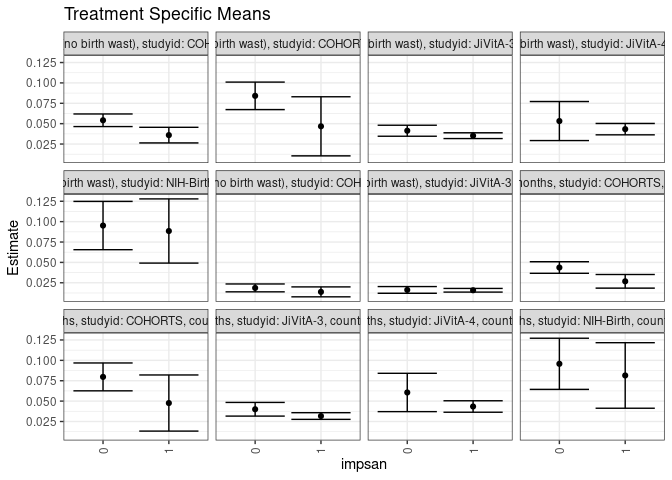

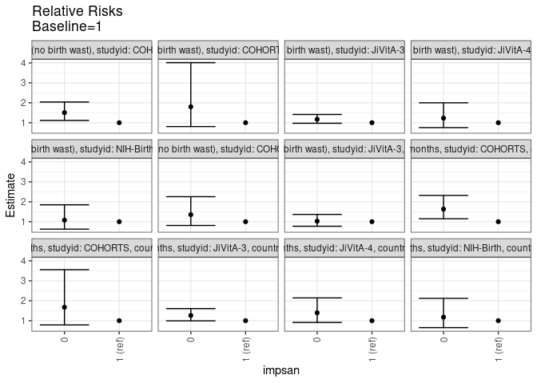

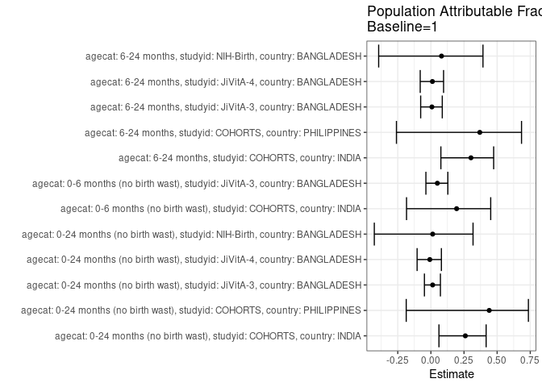

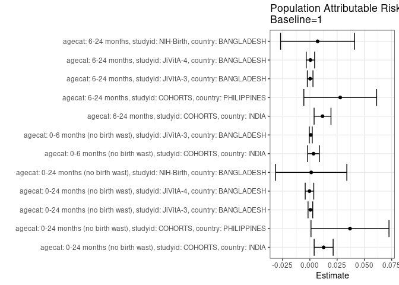

## Results Table

### Parameter: TSM

| agecat | studyid | country | intervention_level | baseline_level | estimate | ci_lower | ci_upper |
| --- | --- | --- | --- | --- | --- | --- | --- |
| 0-24 months (no birth wast) | COHORTS | INDIA | 1 | NA | 0.0359411 | 0.0263607 | 0.0455214 |
| 0-24 months (no birth wast) | COHORTS | INDIA | 0 | NA | 0.0541619 | 0.0464459 | 0.0618779 |
| 0-24 months (no birth wast) | COHORTS | PHILIPPINES | 1 | NA | 0.0467587 | 0.0104859 | 0.0830315 |
| 0-24 months (no birth wast) | COHORTS | PHILIPPINES | 0 | NA | 0.0841426 | 0.0672737 | 0.1010114 |
| 0-24 months (no birth wast) | JiVitA-3 | BANGLADESH | 1 | NA | 0.0352562 | 0.0317037 | 0.0388088 |
| 0-24 months (no birth wast) | JiVitA-3 | BANGLADESH | 0 | NA | 0.0413519 | 0.0346057 | 0.0480982 |
| 0-24 months (no birth wast) | JiVitA-4 | BANGLADESH | 1 | NA | 0.0432799 | 0.0363019 | 0.0502578 |
| 0-24 months (no birth wast) | JiVitA-4 | BANGLADESH | 0 | NA | 0.0532160 | 0.0292681 | 0.0771639 |
| 0-24 months (no birth wast) | NIH-Birth | BANGLADESH | 1 | NA | 0.0884885 | 0.0491060 | 0.1278710 |
| 0-24 months (no birth wast) | NIH-Birth | BANGLADESH | 0 | NA | 0.0951895 | 0.0655435 | 0.1248356 |
| 0-6 months (no birth wast) | COHORTS | INDIA | 1 | NA | 0.0138204 | 0.0077222 | 0.0199187 |
| 0-6 months (no birth wast) | COHORTS | INDIA | 0 | NA | 0.0186835 | 0.0138491 | 0.0235179 |
| 0-6 months (no birth wast) | JiVitA-3 | BANGLADESH | 1 | NA | 0.0157896 | 0.0135345 | 0.0180448 |
| 0-6 months (no birth wast) | JiVitA-3 | BANGLADESH | 0 | NA | 0.0162242 | 0.0121201 | 0.0203283 |
| 6-24 months | COHORTS | INDIA | 1 | NA | 0.0267925 | 0.0184209 | 0.0351641 |
| 6-24 months | COHORTS | INDIA | 0 | NA | 0.0437096 | 0.0366056 | 0.0508137 |
| 6-24 months | COHORTS | PHILIPPINES | 1 | NA | 0.0476190 | 0.0131777 | 0.0820604 |
| 6-24 months | COHORTS | PHILIPPINES | 0 | NA | 0.0797101 | 0.0626228 | 0.0967975 |
| 6-24 months | JiVitA-3 | BANGLADESH | 1 | NA | 0.0316866 | 0.0275773 | 0.0357959 |
| 6-24 months | JiVitA-3 | BANGLADESH | 0 | NA | 0.0400001 | 0.0316001 | 0.0484001 |
| 6-24 months | JiVitA-4 | BANGLADESH | 1 | NA | 0.0433844 | 0.0363459 | 0.0504230 |
| 6-24 months | JiVitA-4 | BANGLADESH | 0 | NA | 0.0605934 | 0.0370736 | 0.0841132 |
| 6-24 months | NIH-Birth | BANGLADESH | 1 | NA | 0.0814656 | 0.0412602 | 0.1216710 |
| 6-24 months | NIH-Birth | BANGLADESH | 0 | NA | 0.0957493 | 0.0643643 | 0.1271343 |

### Parameter: E(Y)

| agecat | studyid | country | intervention_level | baseline_level | estimate | ci_lower | ci_upper |
| --- | --- | --- | --- | --- | --- | --- | --- |
| 0-24 months (no birth wast) | COHORTS | INDIA | NA | NA | 0.0485681 | 0.0427068 | 0.0544294 |
| 0-24 months (no birth wast) | COHORTS | PHILIPPINES | NA | NA | 0.0835443 | 0.0677832 | 0.0993054 |
| 0-24 months (no birth wast) | JiVitA-3 | BANGLADESH | NA | NA | 0.0357332 | 0.0331536 | 0.0383127 |
| 0-24 months (no birth wast) | JiVitA-4 | BANGLADESH | NA | NA | 0.0429288 | 0.0372183 | 0.0486393 |
| 0-24 months (no birth wast) | NIH-Birth | BANGLADESH | NA | NA | 0.0897010 | 0.0668555 | 0.1125465 |
| 0-6 months (no birth wast) | COHORTS | INDIA | NA | NA | 0.0171501 | 0.0134470 | 0.0208532 |
| 0-6 months (no birth wast) | JiVitA-3 | BANGLADESH | NA | NA | 0.0165986 | 0.0147809 | 0.0184163 |
| 6-24 months | COHORTS | INDIA | NA | NA | 0.0384080 | 0.0330939 | 0.0437221 |
| 6-24 months | COHORTS | PHILIPPINES | NA | NA | 0.0754717 | 0.0599461 | 0.0909973 |
| 6-24 months | JiVitA-3 | BANGLADESH | NA | NA | 0.0319334 | 0.0290402 | 0.0348265 |
| 6-24 months | JiVitA-4 | BANGLADESH | NA | NA | 0.0438871 | 0.0380629 | 0.0497114 |
| 6-24 months | NIH-Birth | BANGLADESH | NA | NA | 0.0885609 | 0.0646203 | 0.1125014 |

### Parameter: RR

| agecat | studyid | country | intervention_level | baseline_level | estimate | ci_lower | ci_upper |
| --- | --- | --- | --- | --- | --- | --- | --- |
| 0-24 months (no birth wast) | COHORTS | INDIA | 1 | 1 | 1.000000 | 1.0000000 | 1.000000 |
| 0-24 months (no birth wast) | COHORTS | INDIA | 0 | 1 | 1.506964 | 1.1144635 | 2.037700 |
| 0-24 months (no birth wast) | COHORTS | PHILIPPINES | 1 | 1 | 1.000000 | 1.0000000 | 1.000000 |
| 0-24 months (no birth wast) | COHORTS | PHILIPPINES | 0 | 1 | 1.799507 | 0.8072041 | 4.011657 |
| 0-24 months (no birth wast) | JiVitA-3 | BANGLADESH | 1 | 1 | 1.000000 | 1.0000000 | 1.000000 |
| 0-24 months (no birth wast) | JiVitA-3 | BANGLADESH | 0 | 1 | 1.172897 | 0.9730387 | 1.413805 |
| 0-24 months (no birth wast) | JiVitA-4 | BANGLADESH | 1 | 1 | 1.000000 | 1.0000000 | 1.000000 |
| 0-24 months (no birth wast) | JiVitA-4 | BANGLADESH | 0 | 1 | 1.229578 | 0.7564003 | 1.998759 |
| 0-24 months (no birth wast) | NIH-Birth | BANGLADESH | 1 | 1 | 1.000000 | 1.0000000 | 1.000000 |
| 0-24 months (no birth wast) | NIH-Birth | BANGLADESH | 0 | 1 | 1.075727 | 0.6263847 | 1.847410 |
| 0-6 months (no birth wast) | COHORTS | INDIA | 1 | 1 | 1.000000 | 1.0000000 | 1.000000 |
| 0-6 months (no birth wast) | COHORTS | INDIA | 0 | 1 | 1.351875 | 0.8106830 | 2.254353 |
| 0-6 months (no birth wast) | JiVitA-3 | BANGLADESH | 1 | 1 | 1.000000 | 1.0000000 | 1.000000 |
| 0-6 months (no birth wast) | JiVitA-3 | BANGLADESH | 0 | 1 | 1.027521 | 0.7728142 | 1.366176 |
| 6-24 months | COHORTS | INDIA | 1 | 1 | 1.000000 | 1.0000000 | 1.000000 |
| 6-24 months | COHORTS | INDIA | 0 | 1 | 1.631413 | 1.1477146 | 2.318963 |
| 6-24 months | COHORTS | PHILIPPINES | 1 | 1 | 1.000000 | 1.0000000 | 1.000000 |
| 6-24 months | COHORTS | PHILIPPINES | 0 | 1 | 1.673913 | 0.7872542 | 3.559187 |
| 6-24 months | JiVitA-3 | BANGLADESH | 1 | 1 | 1.000000 | 1.0000000 | 1.000000 |
| 6-24 months | JiVitA-3 | BANGLADESH | 0 | 1 | 1.262366 | 0.9916049 | 1.607060 |
| 6-24 months | JiVitA-4 | BANGLADESH | 1 | 1 | 1.000000 | 1.0000000 | 1.000000 |
| 6-24 months | JiVitA-4 | BANGLADESH | 0 | 1 | 1.396663 | 0.9108316 | 2.141634 |
| 6-24 months | NIH-Birth | BANGLADESH | 1 | 1 | 1.000000 | 1.0000000 | 1.000000 |
| 6-24 months | NIH-Birth | BANGLADESH | 0 | 1 | 1.175334 | 0.6516607 | 2.119831 |

### Parameter: PAR

| agecat | studyid | country | intervention_level | baseline_level | estimate | ci_lower | ci_upper |
| --- | --- | --- | --- | --- | --- | --- | --- |
| 0-24 months (no birth wast) | COHORTS | INDIA | 1 | NA | 0.0126270 | 0.0039211 | 0.0213330 |
| 0-24 months (no birth wast) | COHORTS | PHILIPPINES | 1 | NA | 0.0367856 | 0.0010345 | 0.0725368 |
| 0-24 months (no birth wast) | JiVitA-3 | BANGLADESH | 1 | NA | 0.0004769 | -0.0016732 | 0.0026270 |
| 0-24 months (no birth wast) | JiVitA-4 | BANGLADESH | 1 | NA | -0.0003511 | -0.0042800 | 0.0035779 |
| 0-24 months (no birth wast) | NIH-Birth | BANGLADESH | 1 | NA | 0.0012125 | -0.0314648 | 0.0338898 |
| 0-6 months (no birth wast) | COHORTS | INDIA | 1 | NA | 0.0033297 | -0.0020334 | 0.0086928 |
| 0-6 months (no birth wast) | JiVitA-3 | BANGLADESH | 1 | NA | 0.0008090 | -0.0005627 | 0.0021807 |
| 6-24 months | COHORTS | INDIA | 1 | NA | 0.0116155 | 0.0038778 | 0.0193531 |
| 6-24 months | COHORTS | PHILIPPINES | 1 | NA | 0.0278527 | -0.0055227 | 0.0612280 |
| 6-24 months | JiVitA-3 | BANGLADESH | 1 | NA | 0.0002467 | -0.0023503 | 0.0028438 |
| 6-24 months | JiVitA-4 | BANGLADESH | 1 | NA | 0.0005027 | -0.0033580 | 0.0043634 |
| 6-24 months | NIH-Birth | BANGLADESH | 1 | NA | 0.0070953 | -0.0268500 | 0.0410405 |

### Parameter: PAF

| agecat | studyid | country | intervention_level | baseline_level | estimate | ci_lower | ci_upper |
| --- | --- | --- | --- | --- | --- | --- | --- |
| 0-24 months (no birth wast) | COHORTS | INDIA | 1 | NA | 0.2599863 | 0.0608783 | 0.4168804 |
| 0-24 months (no birth wast) | COHORTS | PHILIPPINES | 1 | NA | 0.4403129 | -0.1861707 | 0.7359152 |
| 0-24 months (no birth wast) | JiVitA-3 | BANGLADESH | 1 | NA | 0.0133468 | -0.0488296 | 0.0718372 |
| 0-24 months (no birth wast) | JiVitA-4 | BANGLADESH | 1 | NA | -0.0081779 | -0.1039732 | 0.0793049 |
| 0-24 months (no birth wast) | NIH-Birth | BANGLADESH | 1 | NA | 0.0135172 | -0.4270357 | 0.3180631 |
| 0-6 months (no birth wast) | COHORTS | INDIA | 1 | NA | 0.1941494 | -0.1838194 | 0.4514406 |
| 0-6 months (no birth wast) | JiVitA-3 | BANGLADESH | 1 | NA | 0.0487375 | -0.0376700 | 0.1279498 |
| 6-24 months | COHORTS | INDIA | 1 | NA | 0.3024230 | 0.0753576 | 0.4737278 |
| 6-24 months | COHORTS | PHILIPPINES | 1 | NA | 0.3690476 | -0.2598982 | 0.6840214 |
| 6-24 months | JiVitA-3 | BANGLADESH | 1 | NA | 0.0077268 | -0.0771194 | 0.0858894 |
| 6-24 months | JiVitA-4 | BANGLADESH | 1 | NA | 0.0114547 | -0.0805877 | 0.0956570 |
| 6-24 months | NIH-Birth | BANGLADESH | 1 | NA | 0.0801175 | -0.3941132 | 0.3930307 |